# Course 5 Assignment1

Ali Murat Okur

May 12, 2017

Part 1 - What is mean total number of steps taken per day?

Calculated this on a day-by-day basis as it makes more sense for later portions of the assignment.

```r
#read in data
activity <- read.csv("activity.csv", sep =",", stringsAsFactors = FALSE, na.strings = "NA")
#convert date to Date class
activity$date <- as.Date(activity$date)
```

Part 1 - What is mean total number of steps taken per day?

```r
#Use complete cases only
activityComplete <- activity[complete.cases(activity),]

#Aggregate by day
totalStepsByDay <- aggregate(steps ~ date, data = activityComplete, FUN=sum)
head(totalStepsByDay)
```

```
##         date steps
## 1 2012-10-02   126
## 2 2012-10-03 11352
## 3 2012-10-04 12116
## 4 2012-10-05 13294
## 5 2012-10-06 15420
## 6 2012-10-07 11015
```

```r
#mean and median of all days
mean(totalStepsByDay$steps)
```

```
## [1] 10766
```

```r
median(totalStepsByDay$steps)
```

```
## [1] 10765
```

The first plot below shows total steps taken per separated into 20 bins

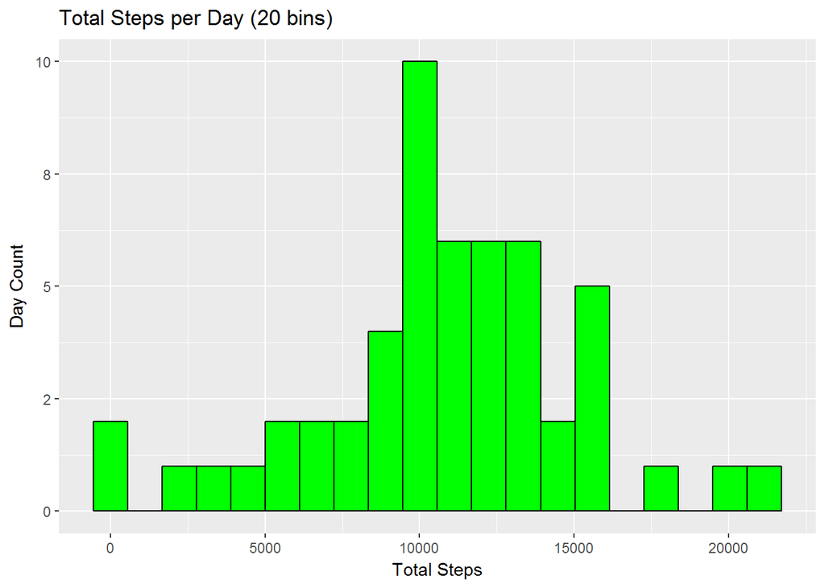

```r
p1 <- ggplot(data = totalStepsByDay, aes(totalStepsByDay$steps)) +
  geom_histogram(bins = 20, fill = "green", col="black") +
  labs(x = "Total Steps") +
  labs(y = "Day Count") +
  ylim(c(0,10)) +
  labs(title = "Total Steps per Day (20 bins)")
p1
```

Part 2 - What is the average daily activity pattern?

```r
##Group by interval and calculate mean, and max steps
byInterval <- group_by(activityComplete, interval )
meanByInterval <- as.data.frame(summarize(byInterval, mean = mean(steps)))
maxStepsData <- subset(meanByInterval, meanByInterval$mean==max(meanByInterval$mean))
```

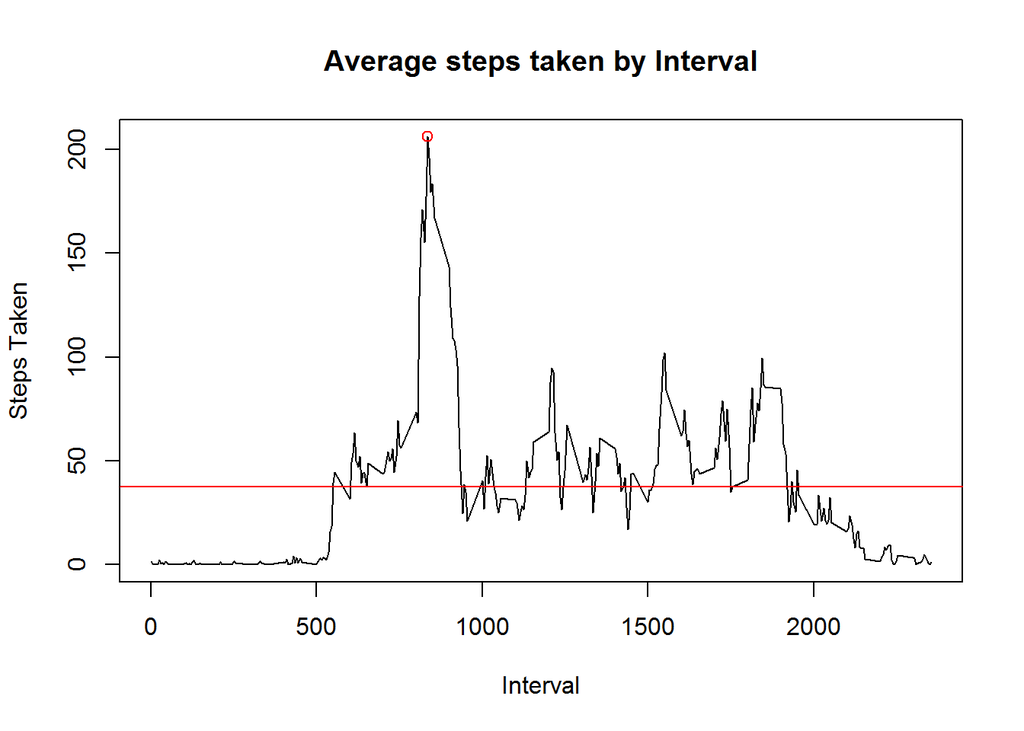

```r
##Plot the average value of the intervals and highlight average and max values
plot(meanByInterval, type = "l", xlab = "Interval", ylab = "Steps Taken", main="Average steps taken by Interval")
abline(h=mean(activityComplete$steps), col = "red")
points(maxStepsData$interval[], maxStepsData$mean[], col="red")
```

The maximum interval and steps shown by the point above at an interval of 835 with 206.2 steps

Part 3 - Imputing missing values

```r
#Function returnMean - Input: missing interval value. Output:matching mean steps from interval across dataset
returnMean <- function(interval){
  #lookup and return valid mean value
  meanByInterval[match(interval, meanByInterval$interval),2]
}

#loop through all the NA values and assign based on interval
activityImputed <- activity
for (index in 1:nrow(activityImputed)) {
  rowData = activityImputed[index, ]
  #if steps is NA then impute new value by interval
  if (is.na(rowData$steps)) {
    rowData$steps <- returnMean(rowData$interval)
    activityImputed[index, ] <- rowData
  }
}
#Aggregate by day with imputed values of intervals
totalStepsByDayImputed <- aggregate(steps ~ date, data = activityImputed, FUN=sum)
#Mean and median of all days imputed
mean(totalStepsByDayImputed$steps)
```

```
## [1] 10766
```

```r
median(totalStepsByDayImputed$steps)
```

```
## [1] 10766
```

The results of the imputation are mean and median of 10766 and 10766, respectively. This compares to the non-imputed previous values of 10766 and 10765

This may seem incorrect at first but further analysis reveals that 8 days are completely missing:

```r
aggregate(interval ~ date, data = subset(activity, is.na(activity$steps)==TRUE), FUN=length)
```

```
##         date interval
## 1 2012-10-01      288
## 2 2012-10-08      288
## 3 2012-11-01      288
## 4 2012-11-04      288
## 5 2012-11-09      288
## 6 2012-11-10      288
## 7 2012-11-14      288
## 8 2012-11-30      288
```

Thus the imputation method using mean intervals or days will simply skew to the middle as the missing values are filled in the average value of 10766. This is evident in the plot below:

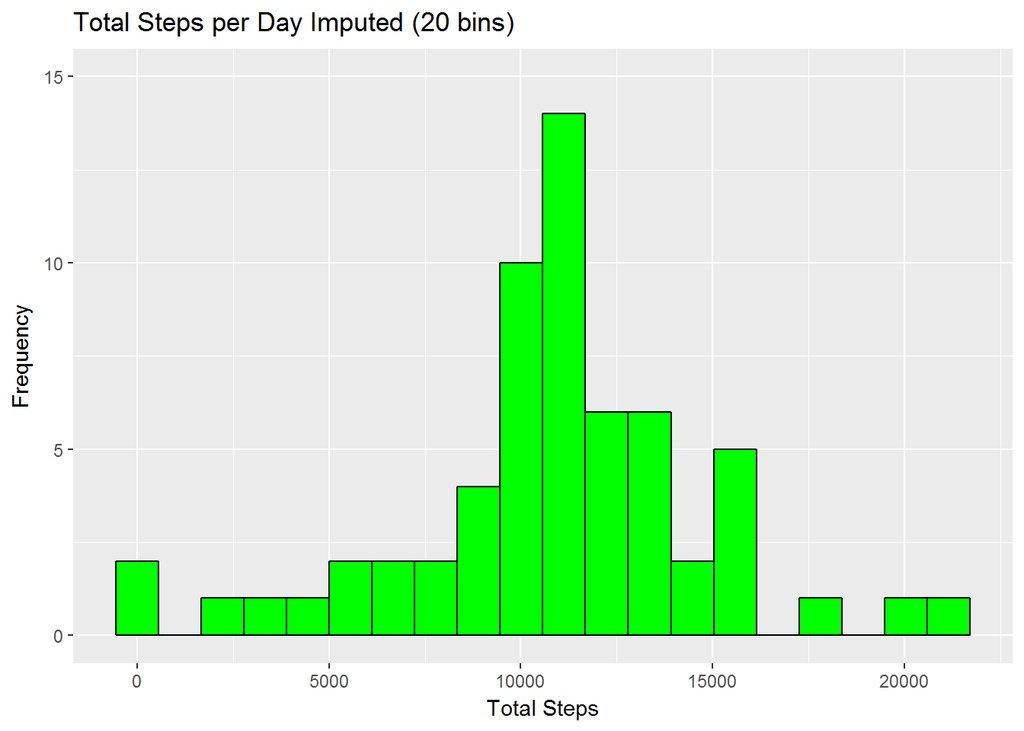

```r
p2 <- ggplot(data = totalStepsByDayImputed, aes(totalStepsByDayImputed$steps)) +
  geom_histogram(bins = 20, fill = "green", col="black") +
  labs(x = "Total Steps") +
  labs(y = "Frequency") +
  ylim(c(0,15)) +
  labs(title = "Total Steps per Day Imputed (20 bins)")
p2
```

Part 4 - Weekday/weekend activity patterns Are there differences in activity patterns between weekdays and weekends?

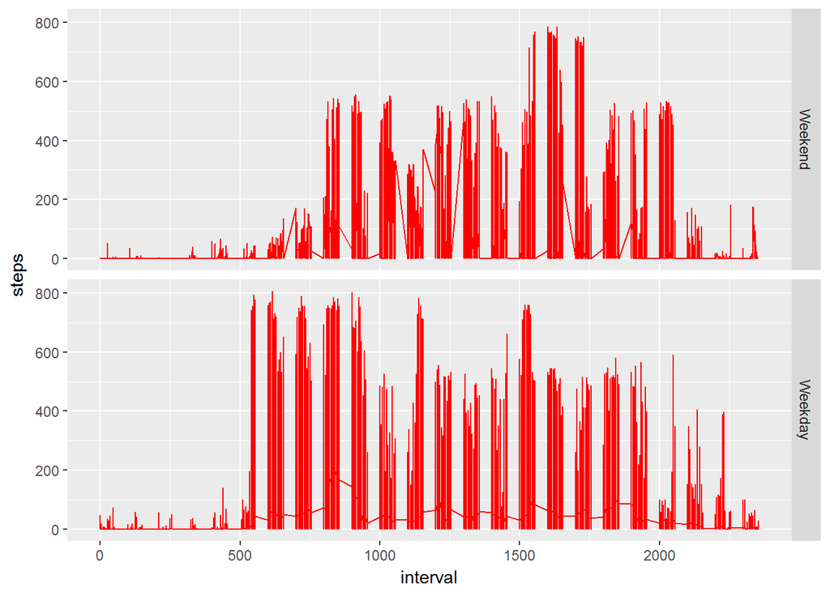

```r
##modified from: http://stackoverflow.com/questions/28893193/creating-factor-variables-weekend-and-weekday-from-date
##categorize imputed activities by weekday/weekend
activityImputed$day <- factor(weekdays(activityImputed$date) %in% c("Saturday", "Sunday"),
                                      levels= c(TRUE, FALSE),
                                      labels= c('Weekend', 'Weekday'))

p3 <- ggplot(activityImputed, aes(interval,steps)) +
  geom_line(color="red") +
  facet_grid(day ~ .)
p3
```

From our plot above we can see that Weekends are more active near the evening hours of 1500 to 1700 Hours in 24hr format while Weekdays are especially active during the morning hours until about 1000. This makes sense given the normal workweek schedule.

As expected hours during regular sleep hours show minimal activity.